# BeachTan Inc. Analytics Workflow

Abby Farrell

October 2, 2020

The goal of the following exploratory data analysis is to aid the Marketing Team of Beach Tan Inc. in understanding factors that contribute to a customer’s spending in upgrade revenue. In a Business Value Proposition previously presented to the team, this solution was pitched as one that would easily allow the team to identify trends leading to a customer spending money in upgrades and in turn tailor marketing techniques to encourage these upgrades.

I am performing an analysis on the customer data provided by Beach Tan to show and document any correlation to upgrade revenue found. The code used throughout this document can be hidden or shown through the option in the upper right-hand corner. The changes tracked throughout this analysis can be found on the public GitHub repository at this link https://github.com/abbyfarrell/BeachTanAnalysis, which includes all the files needed for reproduction.

# 1 Loading & Describing Data

The beginning code chunk includes installing all packages needed for the analysis, as well as reading in the data. The R Package Pacman was used to install all the necessary packages in one step.

```r
library(pacman)
p_load(tidyverse, dplyr, plyr, DataExplorer, corrplot, knitr, ggplot2)
df<-read.csv("BeachTan.csv", stringsAsFactors = TRUE)
```

Next, some of the variables must be recoded in order to ensure accurate results. This includes making sure every variable that is a factor is coded as one. The only variable that had the raw data changed is Gender, where any customer who did not have a given value for gender was coded as “Missing”. These values were kept in the data set for analysis. The output below shows a summary of the variables after the data has been prepped, as well as a plot introducing the data.

```r
#recode as factors
df$UIDStoreLocation <- as.factor(df$UIDStoreLocation)
df$MembershipType <- as.factor(df$MembershipType)
df$MembershipLevel <- as.factor(df$MembershipLevel)
levels(df$MembershipType) <-c('Non Membership', 'Monthly Membership', 'Annual Membership')
levels(df$MembershipLevel) <-c('Non Membership', 'Fast', 'Faster', 'Fastest', 'Instant')
df$Gender = fct_recode(df$Gender, 'Missing' = "", 'Missing' = "#NULL!")

str(df)
```

```
## 'data.frame':    11041 obs. of  12 variables:
##  $ UIDClient       : int  597 17873 26441 31132 31382 44204 50652 81049 98231 9020 ...
##  $ UIDStoreLocation: Factor w/ 10 levels "1","2","3","4",..: 1 1 1 1 1 1 1 1 1 2 ...
##  $ Gender          : Factor w/ 3 levels "Missing","0",..: 2 2 2 2 2 2 2 2 2 2 ...
##  $ DateJoined      : Factor w/ 2840 levels "","1/1/2008",..: 1116 377 1171 1171 1599 2150 1918 1185 2165 2607 ...
##  $ DaysSinceJoined : int  1694 1855 2785 2785 921 2689 2351 2053 1591 1160 ...
##  $ MembershipType  : Factor w/ 3 levels "Non Membership",..: 3 3 3 3 3 3 3 3 3 3 ...
##  $ MembershipLevel : Factor w/ 5 levels "Non Membership",..: 1 1 2 1 1 1 1 5 1 2 ...
##  $ Age             : int  38 48 76 40 20 20 52 40 63 21 ...
##  $ UVTans          : int  189 0 265 327 90 162 2 34 11 306 ...
##  $ SunlessTans     : int  4 26 58 18 0 17 1 2 0 0 ...
##  $ UpgradeRevenue  : int  56 25 15 0 8 0 0 0 0 0 ...
##  $ RetailRevenue   : num  76 171 190 400 67 ...
```

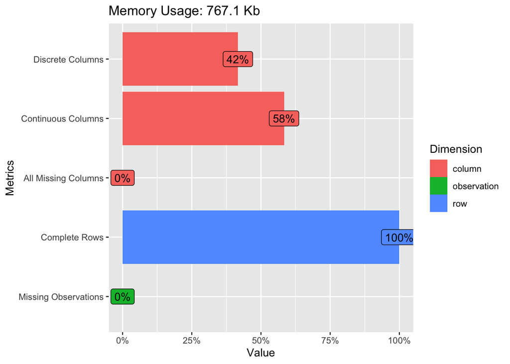

```r
plot_intro (df)
```

# 2 Plotting the Variables

We can see that we now have a relatively straight-forward data set with no missing values. This will allow us to examine any correlation between the given variables and upgrade revenue specifically. A correlation map of the numeric variables is shown below, as well as four tabs for different scatter plots and distribution graphs of the factor variables.

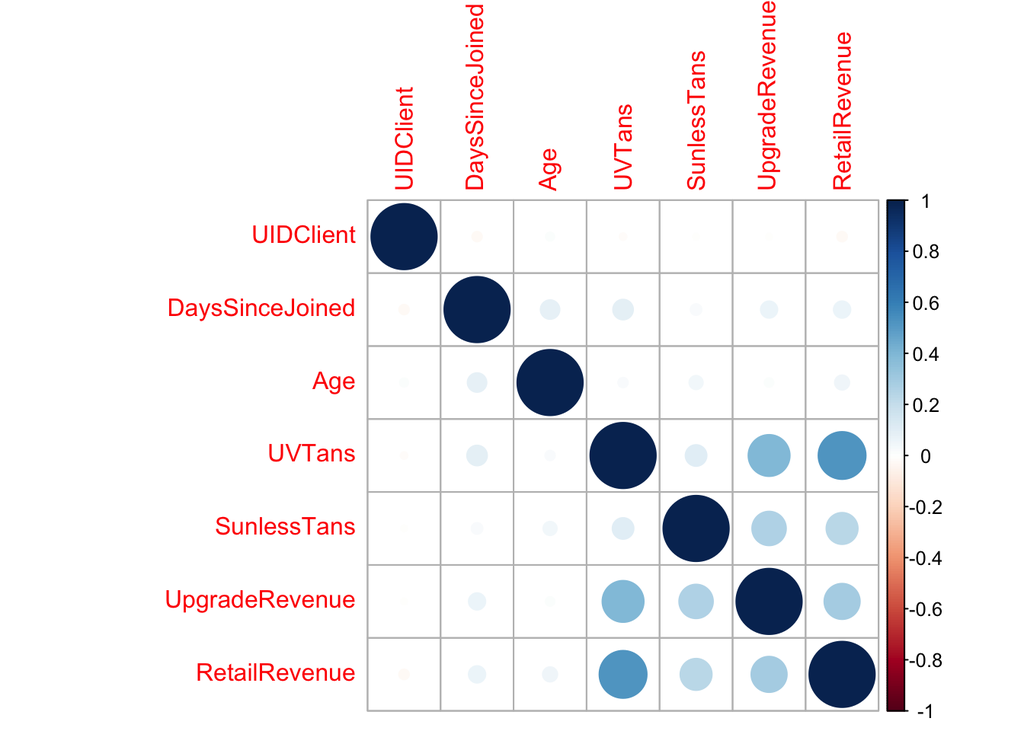

```r
#Find correlation in variables
correlation <- unlist(lapply(df, is.numeric))
dfcorr<-df[,correlation]
M<-cor(dfcorr, use = "complete.obs")
corrplot(M, method='circle')
```

## 2.1 Membership Type

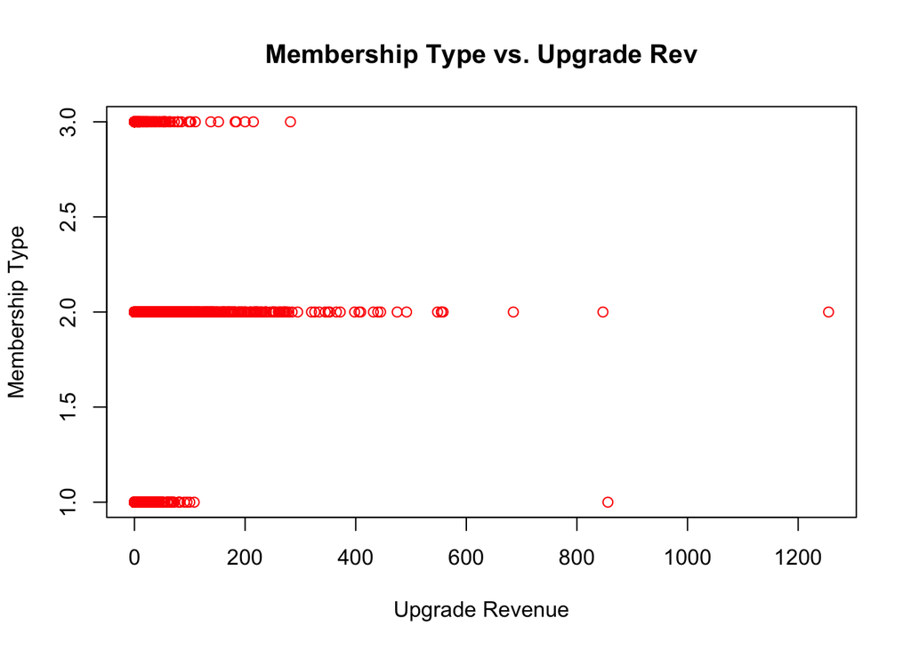

```r
plot(df$UpgradeRevenue, df$MembershipType, main="Membership Type vs. Upgrade Rev", xlab = "Upgrade Revenue", ylab= "Membership Type", col="red")
```

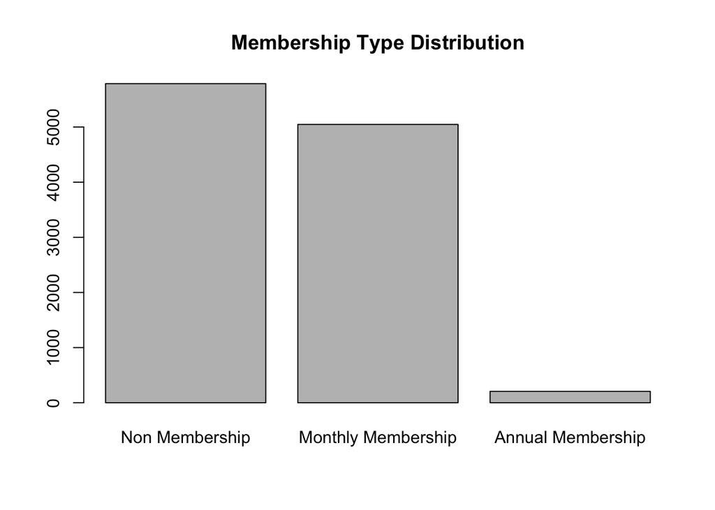

```r
plot(df$MembershipType, main = "Membership Type Distribution")
```

## 2.2 Membership Level

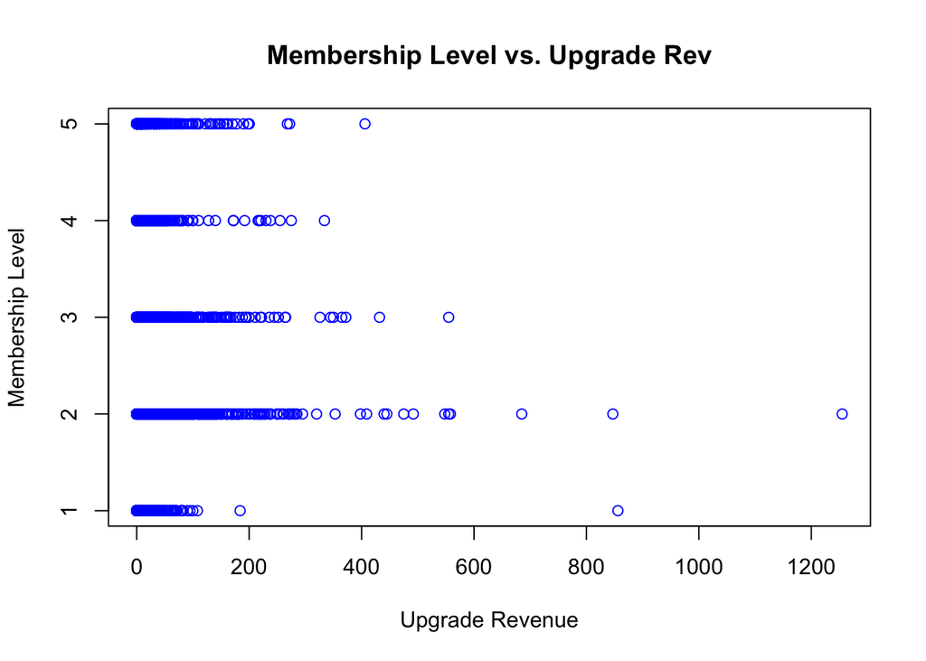

```r
plot(df$UpgradeRevenue, df$MembershipLevel, main="Membership Level vs. Upgrade Rev", xlab = "Upgrade Revenue", ylab= "Membership Level", col="blue")
```

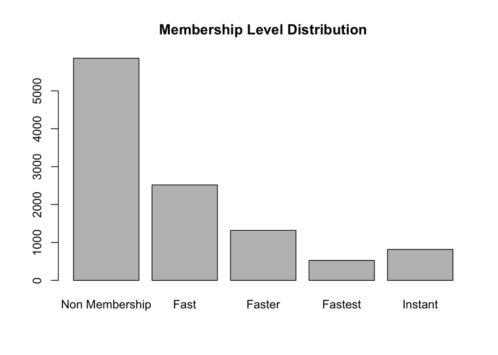

```r
plot(df$MembershipLevel, main = "Membership Level Distribution")
```

## 2.3 Gender

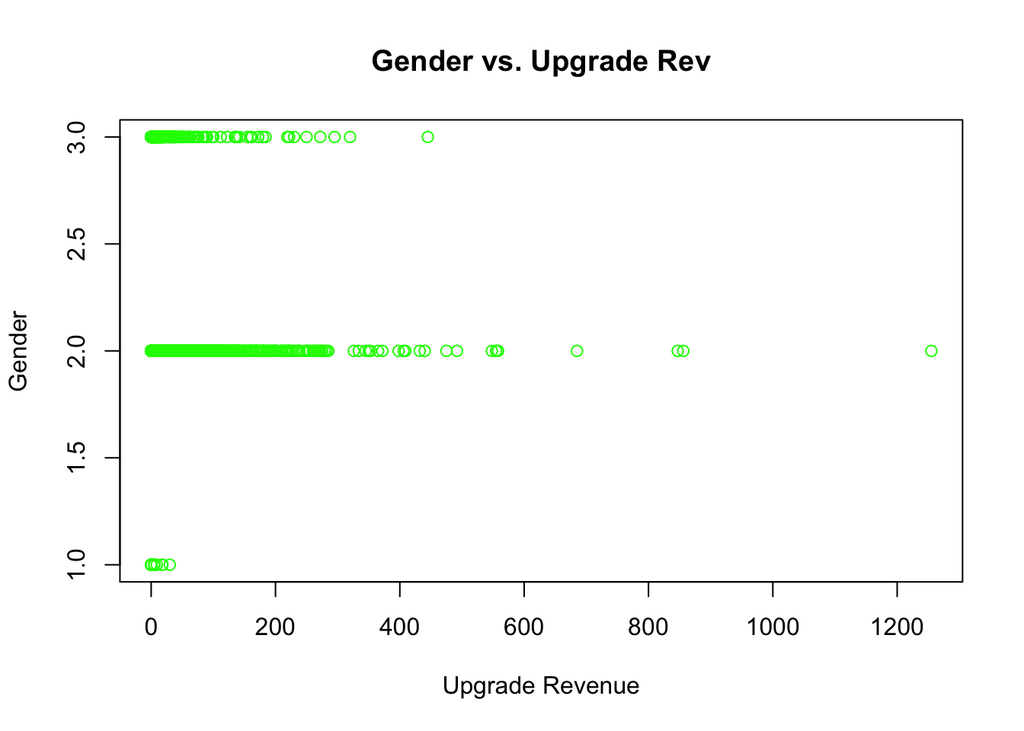

```r
plot(df$UpgradeRevenue, df$Gender, main="Gender vs. Upgrade Rev", xlab = "Upgrade Revenue", ylab= "Gender", col="green")
```

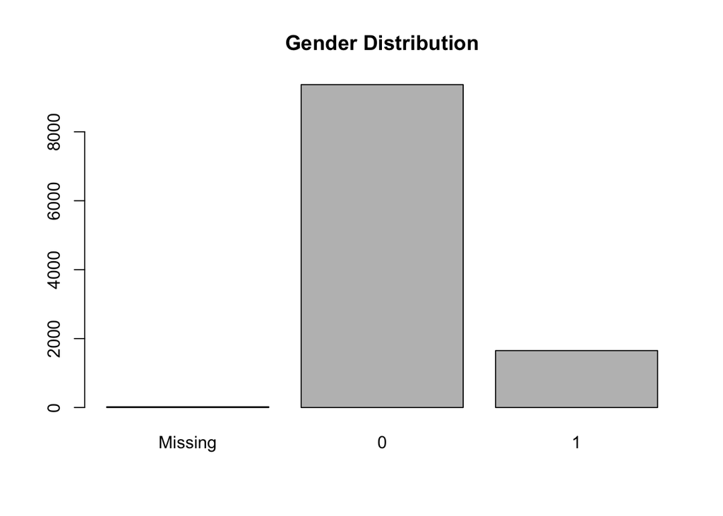

```r
plot(df$Gender, main = "Gender Distribution")
```

## 2.4 Store Location

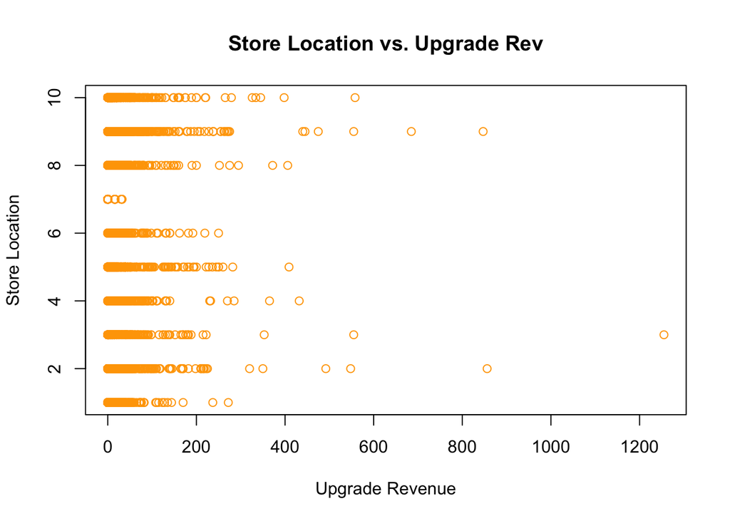

```r
plot(df$UpgradeRevenue, df$UIDStoreLocation, main="Store Location vs. Upgrade Rev", xlab = "Upgrade Revenue", ylab= "Store Location", col="orange")
```

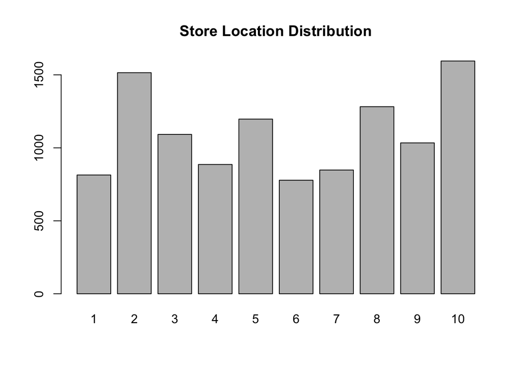

```r
plot(df$UIDStoreLocation, main = "Store Location Distribution")
```

# 3 Analyzing Correlations

There are a couple observations we can make from the graphs above. First, looking at the correlation plot of numeric variables we can see that upgrade revenue has the strongest correlation with the number of UV Tans. The scatter plots showing the different factors against our target variable tells us which membership type and level contributed most to upgrade revenue. Now we can take a closer look at the variables that have the greatest correlation to upgrade revenue to confirm our findings, shown in the graphs in the seperate tabs below.

## 3.1 UV Tans

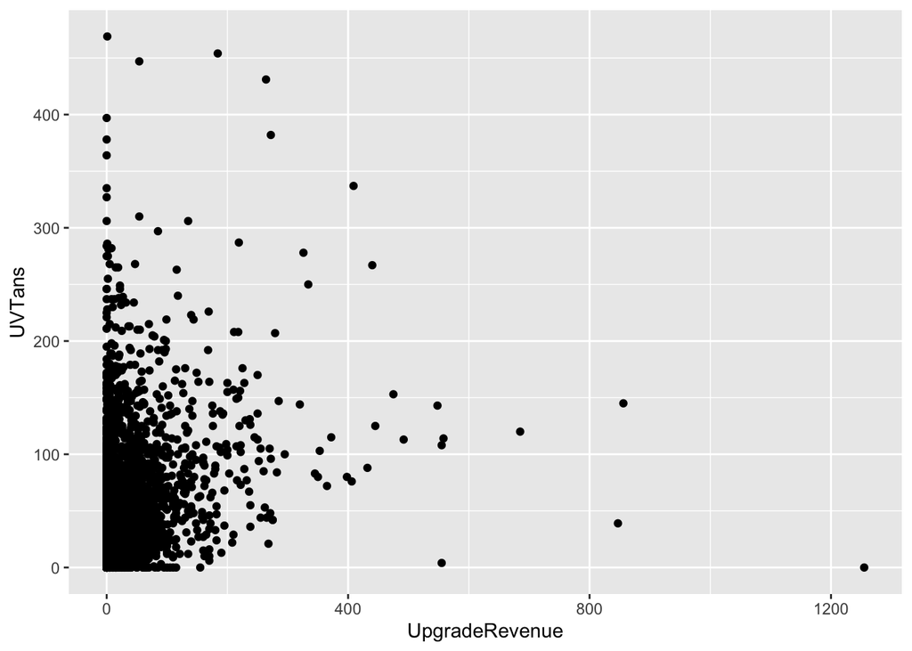

```r
ggplot(data = df) +
  geom_point(mapping = aes(x = UpgradeRevenue, y = UVTans))
```

## 3.2 Membership Level

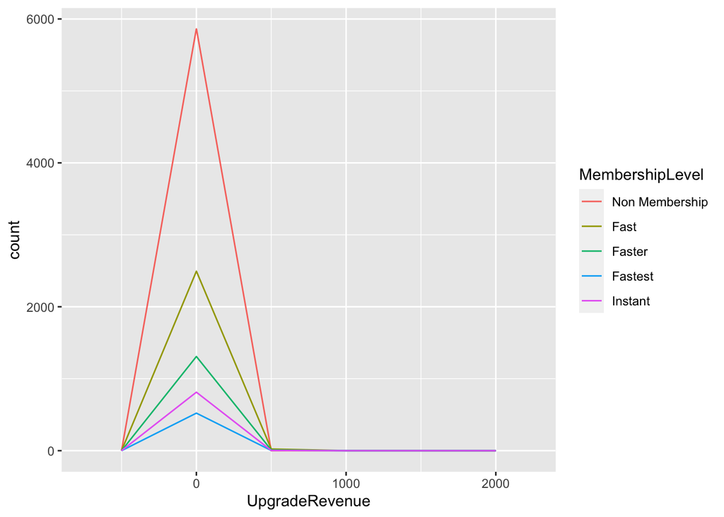

```r
ggplot(data = df, mapping = aes(x = UpgradeRevenue)) +
  geom_freqpoly(mapping = aes(colour = MembershipLevel), binwidth = 500)
```

## 3.3 Membership Type

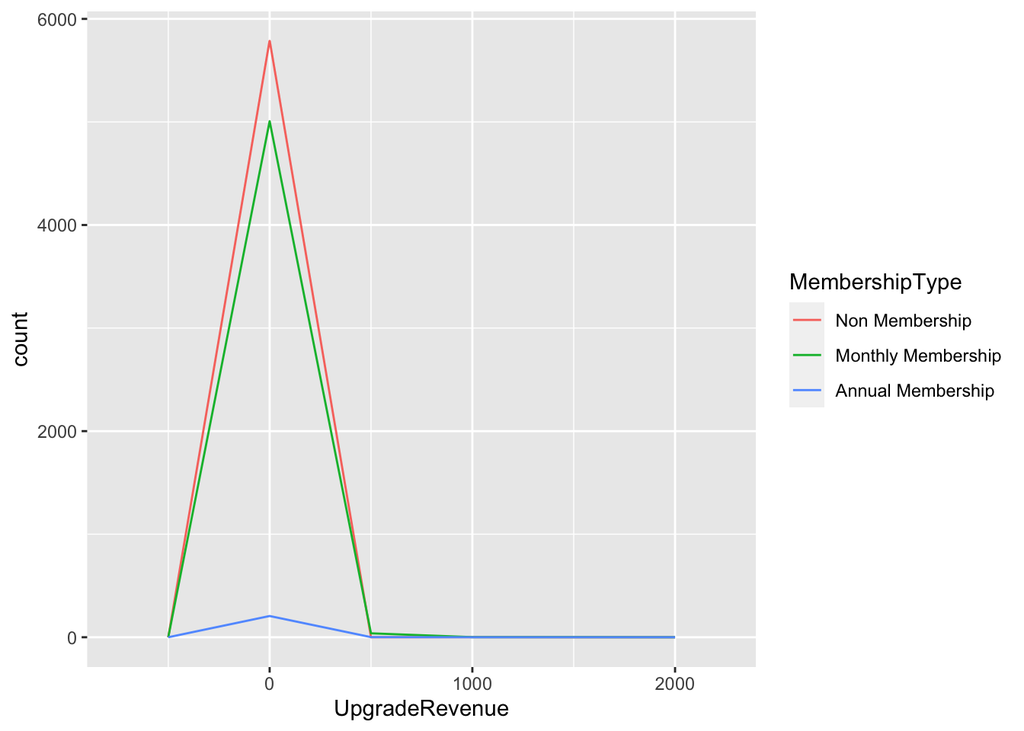

```r
ggplot(data = df, mapping = aes(x = UpgradeRevenue)) +
  geom_freqpoly(mapping = aes(colour = MembershipType), binwidth = 500)
```

# 4 Conclusion

```r
fitmodel <- lm(UpgradeRevenue ~ UVTans + MembershipLevel + MembershipType, data=df)
summary(fitmodel)
```

```
##
## Call:
## lm(formula = UpgradeRevenue ~ UVTans + MembershipLevel + MembershipType,
##     data = df)
##
## Residuals:
##     Min      1Q  Median      3Q     Max
## -186.96   -8.05   -1.70   -0.91 1245.73
##
## Coefficients:
##                                   Estimate Std. Error t value Pr(>|t|)
## (Intercept)                        0.91168    0.44346   2.056  0.03982 *
## UVTans                             0.39589    0.01037  38.190  < 2e-16 ***
## MembershipLevelFast               13.09516    4.90116   2.672  0.00755 **
## MembershipLevelFaster              5.62858    4.96193   1.134  0.25667
## MembershipLevelFastest             1.82336    5.07452   0.359  0.71936
## MembershipLevelInstant             6.10793    4.94663   1.235  0.21694
## MembershipTypeMonthly Membership  -4.73213    4.91597  -0.963  0.33577
## MembershipTypeAnnual Membership  -12.98745    3.95896  -3.281  0.00104 **
## ---
## Signif. codes:  0 '***' 0.001 '**' 0.01 '*' 0.05 '.' 0.1 ' ' 1
##
## Residual standard error: 33.65 on 11033 degrees of freedom
## Multiple R-squared:   0.17,  Adjusted R-squared:  0.1695
## F-statistic: 322.9 on 7 and 11033 DF,  p-value: < 2.2e-16
```

From looking the model, we can see that three of these variables are significant when it comes to upgrade revenue. With all else held constant:

- As the number of UV Tans a customer receives increases by 1, there is a $0.40 increase associated with that customer’s estimated upgrade revenue.
- Customers with the fast membership level are associated with a $13.10 estimated increase in upgrade revenue.
- Customers with an annual membership are associated with a $12.99 estimated *decrease* in upgrade revenue. This negative relationship could be due to the fact that this is already the highest membership level offered by Beach Tan, meaning these customers can not upgrade any more.

Looking at the ANOVA table below gives us a more condensed output of our model. This, most importantly, shows us the sum of squares as well as the F-value for our variables. From this table we can see that in terms of upgrade revenue, all of these variables *are* statistically significant in estimating a customer’s likelihood to upgrade.

```r
anova(fitmodel)
```

|  | Df | Sum Sq | Mean Sq | F value | Pr(>F) |
| --- | --- | --- | --- | --- | --- |
| UVTans | 1 | 2401112.48 | 2401112.48 | 2120.656649 | 0.000000e+00 |
| MembershipLevel | 4 | 137771.68 | 34442.92 | 30.419902 | 3.227236e-25 |
| MembershipType | 2 | 20210.13 | 10105.06 | 8.924768 | 1.340154e-04 |
| Residuals | 11033 | 12492109.00 | 1132.25 | NA | NA |

The conclusion that can be drawn for the Beach Tan Marketing Team is that customers should be pushed to increase their number of UV Tans as well as to upgrade to the fast membership level. Any existing customers of the company who have not yet met this criteria can be sent specific promotions and advertisements to encourage them to upgrade within Beach Tan. This solution will meet the goals of the Business Value Proposition by taking away the pains associated with having to determine marketing techniques for customers on a more individual level. This wastes the time and money of Beach Tan, not to mention that it can be ineffective when reaching the customer. Our model also creates the ability for the team to further examine any predictors that may contribute to other types of revenue within the company. This solution to help the team target customers with specific marketing techniques will increase revenue and customer loyalty for the company overall, as well as encourage more customers to continue to upgrade within Beach Tan in the future.